# Analysis EMG

[Antonio Schettino](https://osf.io/zbv65/)

2020-03-23

# Cue & Target

```r
EMG <- read_csv("EMG.csv") %>%
  pivot_longer(
    Reappraisal_Unexpected:Appraisal_Expected,
    names_to = "condition",
    values_to = "amplitude"
  ) %>%
  separate(
    condition,
    c("ER_Strategy", "Expectation"),
    sep = "_",
    remove = TRUE
  ) %>%
  mutate(
    Participant = as_factor(Participant),
    Believed_Story = as_factor(Believed_Story),
    Stimulus = as_factor(Stimulus),
    ER_Strategy = as_factor(ER_Strategy),
    Expectation = as_factor(Expectation)
  )

# summary
EMG_summary <-
  EMG %>%
  group_by(Stimulus, ER_Strategy, Expectation) %>%
  summarize(
    median = median(amplitude),
    mad = mad(amplitude)
  )

kable(
  EMG_summary,
  digits = c(0, 0, 0, 5, 5),
  caption = "Descriptive statistics of EMG amplitude, separately for each condition."
) %>%
  kable_styling(bootstrap_options = c("striped", "hover", "condensed", "responsive"))
```

Descriptive statistics of EMG amplitude, separately for each condition.

| Stimulus | ER_Strategy | Expectation | median | mad |
| --- | --- | --- | --- | --- |
| cue | Reappraisal | Unexpected | 0.00129 | 0.0033 |
| cue | Reappraisal | Expected | 0.00069 | 0.0027 |
| cue | Appraisal | Unexpected | -0.00065 | 0.0042 |
| cue | Appraisal | Expected | 0.00114 | 0.0040 |
| target | Reappraisal | Unexpected | -0.00022 | 0.0030 |
| target | Reappraisal | Expected | 0.00055 | 0.0027 |
| target | Appraisal | Unexpected | 0.00129 | 0.0053 |
| target | Appraisal | Expected | 0.00054 | 0.0040 |

## Plot

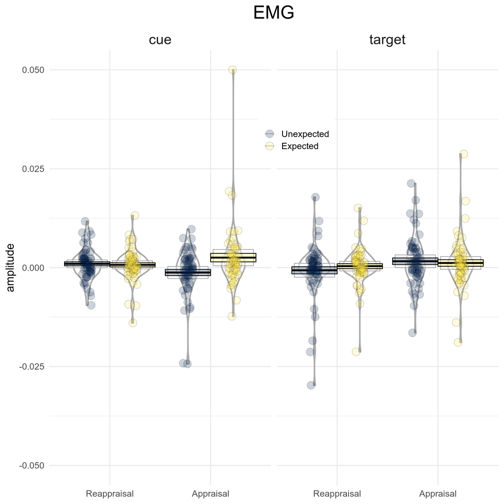

**Figure 1**. EMG amplitude in response to cue and target. **Note**: 18 values are outside the plot.

```r
# plot
EMG %>%
  ggplot(
    aes(
      x = ER_Strategy,
      y = amplitude,
      color = Expectation,
      fill = Expectation
    )
  ) +
  geom_pirate(
    bars = FALSE,
    cis = TRUE,
    lines = TRUE, lines_params = list(color = "black", alpha = .3),
    points = TRUE, points_params = list(color = "black", shape = 21, size = 5, alpha = .2),
    violins = TRUE, violins_params = list(size = 1),
    show.legend = TRUE
  ) +
  scale_color_viridis_d(option = "cividis") +
  scale_fill_viridis_d(option = "cividis") +
  scale_y_continuous(limits = c(-.05, .05)) +
  ggtitle("EMG") +
  facet_wrap(. ~ Stimulus) +
  theme_custom +
  theme(
    legend.position = c(.55, .8),
    axis.title.x = element_blank()
  )
```

## Analysis

Repeated measures nonparametric ANOVA (Aligned Rank Transform).

```r
# repeated measures nonparametric ANOVA, Aligned Rank Transform
all_ART <- anova(
  art(amplitude ~ Stimulus * ER_Strategy * Expectation + Error(Participant),
    data = EMG
  )
) %>%
  mutate(
    eta.sq.part = `Sum Sq` / (`Sum Sq` + `Sum Sq.res`) # partial eta squared
  )

all_ART %>%
  dplyr::select(`Term`, `Df`, `Df.res`, `F` = `F value`, p.value = `Pr(>F)`, `eta.sq.part`) %>%
  kable(.,
    digits = c(0, 0, 0, 2, 3, 3),
    caption = "Repeated measures nonparametric ANOVA (Aligned Rank Transform)."
  ) %>%
  kable_styling(bootstrap_options = c("striped", "hover", "condensed", "responsive"))
```

Repeated measures nonparametric ANOVA (Aligned Rank Transform).

| Term | Df | Df.res | F | p.value | eta.sq.part |
| --- | --- | --- | --- | --- | --- |
| Stimulus | 1 | 420 | 1.7 | 0.199 | 0.004 |
| ER_Strategy | 1 | 420 | 1.5 | 0.223 | 0.004 |
| Expectation | 1 | 420 | 2.0 | 0.156 | 0.005 |
| Stimulus:ER_Strategy | 1 | 420 | 3.7 | 0.056 | 0.009 |
| Stimulus:Expectation | 1 | 420 | 1.3 | 0.248 | 0.003 |
| ER_Strategy:Expectation | 1 | 420 | 0.0 | 0.947 | 0.000 |
| Stimulus:ER_Strategy:Expectation | 1 | 420 | 11.2 | 0.001 | 0.026 |

# Cue

Analyze EMG following cue presentation.

```r
# keep only EMG in response to cue
EMG_cue <- filter(EMG, Stimulus == "cue") %>%
  dplyr::select(-Stimulus)
```

## Plot

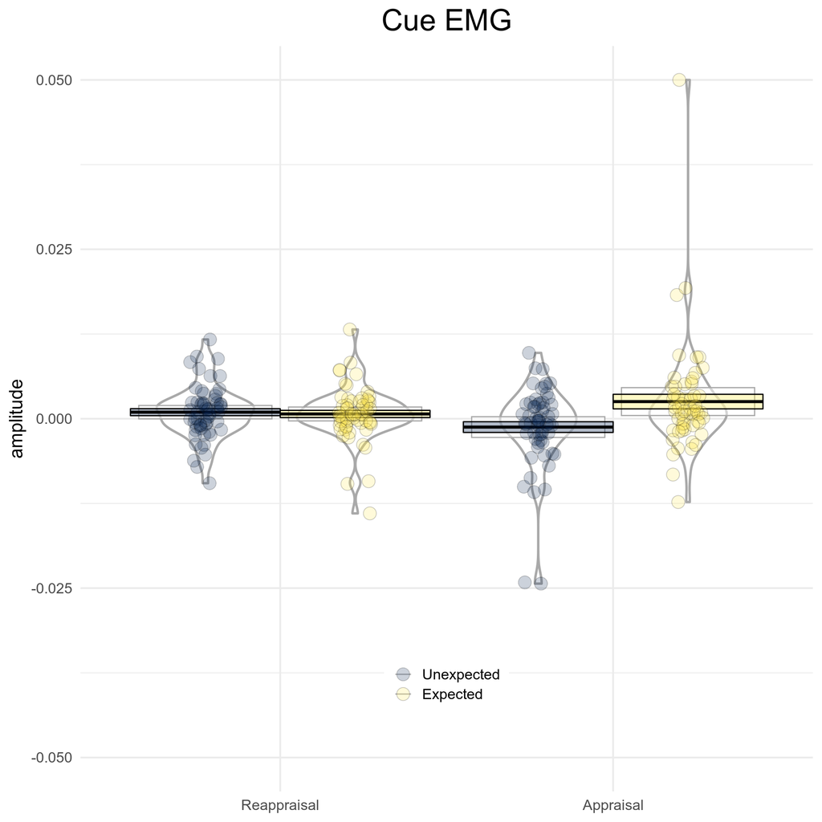

**Figure 2**. EMG amplitude in response to cue. **Note**: 9 values are outside the plot.

```r
# plot
EMG_cue %>%
  ggplot(
    aes(
      x = ER_Strategy,
      y = amplitude,
      color = Expectation,
      fill = Expectation
    )
  ) +
  geom_pirate(
    bars = FALSE,
    cis = TRUE,
    lines = TRUE, lines_params = list(color = "black", alpha = .3),
    points = TRUE, points_params = list(color = "black", shape = 21, size = 5, alpha = .2),
    violins = TRUE, violins_params = list(size = 1),
    show.legend = TRUE
  ) +
  scale_color_viridis_d(option = "cividis") +
  scale_fill_viridis_d(option = "cividis") +
  scale_y_continuous(limits = c(-.05, .05)) +
  ggtitle("Cue EMG") +
  theme_custom +
  theme(
    legend.position = c(.5, .15),
    axis.title.x = element_blank()
  )
```

## Analysis

Repeated measures nonparametric ANOVA (Aligned Rank Transform), post-hoc Paired Samples Wilcoxon Tests.

```r
# repeated measures nonparametric ANOVA, Aligned Rank Transform
cue_ART <- anova(
  art(amplitude ~ ER_Strategy * Expectation + Error(Participant),
    data = EMG_cue
  )
) %>%
  mutate(
    eta.sq.part = `Sum Sq` / (`Sum Sq` + `Sum Sq.res`) # partial eta squared
  )

cue_ART %>%
  dplyr::select(`Term`, `Df`, `Df.res`, `F` = `F value`, p.value = `Pr(>F)`, `eta.sq.part`) %>%
  kable(.,
    digits = c(0, 0, 0, 2, 3, 3),
    caption = "Repeated measures nonparametric ANOVA (Aligned Rank Transform)."
  ) %>%
  kable_styling(bootstrap_options = c("striped", "hover", "condensed", "responsive"))
```

Repeated measures nonparametric ANOVA (Aligned Rank Transform).

| Term | Df | Df.res | F | p.value | eta.sq.part |
| --- | --- | --- | --- | --- | --- |
| ER_Strategy | 1 | 180 | 0.36 | 0.552 | 0.002 |
| Expectation | 1 | 180 | 4.51 | 0.035 | 0.024 |
| ER_Strategy:Expectation | 1 | 180 | 7.86 | 0.006 | 0.042 |

```r
## post-hoc analyses
# Appraisal, Expected vs. Unexpected
# Paired Samples Wilcoxon Test
EMG_Appraisal_ExpectedUnexpected_Wilcoxon <-
  wilcox.test(filter(EMG_cue, ER_Strategy == "Appraisal" & Expectation == "Expected")$amplitude,
    filter(EMG_cue, ER_Strategy == "Appraisal" & Expectation == "Unexpected")$amplitude,
    alternative = "two.sided",
    mu = 0,
    paired = TRUE,
    exact = TRUE,
    correct = TRUE,
    conf.int = TRUE, conf.level = 0.95
  )

# effect size r
EMG_Appraisal_ExpectedUnexpected_r <-
  wilcoxonPairedR(filter(EMG_cue, ER_Strategy == "Appraisal" & Expectation %in% c("Expected", "Unexpected"))$amplitude,
    filter(EMG_cue, ER_Strategy == "Appraisal" & Expectation %in% c("Expected", "Unexpected"))$Expectation,
    ci = TRUE, conf = 0.95,
    type = "bca", R = 5000,
    cases = TRUE
  )

# Reappraisal, Expected vs. Unexpected
# Paired Samples Wilcoxon Test
EMG_Reappraisal_ExpectedUnexpected_Wilcoxon <-
  wilcox.test(filter(EMG_cue, ER_Strategy == "Reappraisal" & Expectation == "Expected")$amplitude,
    filter(EMG_cue, ER_Strategy == "Reappraisal" & Expectation == "Unexpected")$amplitude,
    alternative = "two.sided",
    mu = 0,
    paired = TRUE,
    exact = TRUE,
    correct = TRUE,
    conf.int = TRUE, conf.level = 0.95
  )

# effect size r
EMG_Reappraisal_ExpectedUnexpected_r <-
  wilcoxonPairedR(filter(EMG_cue, ER_Strategy == "Reappraisal" & Expectation %in% c("Expected", "Unexpected"))$amplitude,
    filter(EMG_cue, ER_Strategy == "Reappraisal" & Expectation %in% c("Expected", "Unexpected"))$Expectation,
    ci = TRUE, conf = 0.95,
    type = "bca", R = 5000,
    cases = TRUE
  )

# Expected, Appraisal vs. Reappraisal
# Paired Samples Wilcoxon Test
EMG_Expected_AppraisalReappraisal_Wilcoxon <-
  wilcox.test(filter(EMG_cue, ER_Strategy == "Appraisal" & Expectation == "Expected")$amplitude,
    filter(EMG_cue, ER_Strategy == "Reappraisal" & Expectation == "Expected")$amplitude,
    alternative = "two.sided",
    mu = 0,
    paired = TRUE,
    exact = TRUE,
    correct = TRUE,
    conf.int = TRUE, conf.level = 0.95
  )

# effect size r
EMG_Expected_AppraisalReappraisal_r <-
  wilcoxonPairedR(filter(EMG_cue, ER_Strategy %in% c("Appraisal", "Reappraisal") & Expectation == "Expected")$amplitude,
    filter(EMG_cue, ER_Strategy %in% c("Appraisal", "Reappraisal") & Expectation == "Expected")$ER_Strategy,
    ci = TRUE, conf = 0.95,
    type = "bca", R = 5000,
    cases = TRUE
  )

# Unexpected, Appraisal vs. Reappraisal
# Paired Samples Wilcoxon Test
EMG_Unexpected_AppraisalReappraisal_Wilcoxon <-
  wilcox.test(filter(EMG_cue, ER_Strategy == "Appraisal" & Expectation == "Unexpected")$amplitude,
    filter(EMG_cue, ER_Strategy == "Reappraisal" & Expectation == "Unexpected")$amplitude,
    alternative = "two.sided",
    mu = 0,
    paired = TRUE,
    exact = TRUE,
    correct = TRUE,
    conf.int = TRUE, conf.level = 0.95
  )

# effect size r
EMG_Unexpected_AppraisalReappraisal_r <-
  wilcoxonPairedR(filter(EMG_cue, ER_Strategy %in% c("Appraisal", "Reappraisal") & Expectation == "Unexpected")$amplitude,
    filter(EMG_cue, ER_Strategy %in% c("Appraisal", "Reappraisal") & Expectation == "Unexpected")$ER_Strategy,
    ci = TRUE, conf = 0.95,
    type = "bca", R = 5000,
    cases = TRUE
  )

# summary
cue_ART_posthoc <- tibble(
  "comparison" = c(
    "Appraisal, Expected vs. Unexpected", "Reappraisal, Expected vs. Unexpected",
    "Expected, Appraisal vs. Reappraisal", "Unexpected, Appraisal vs. Reappraisal"
  ),
  "V" = c(
    EMG_Appraisal_ExpectedUnexpected_Wilcoxon$statistic, EMG_Reappraisal_ExpectedUnexpected_Wilcoxon$statistic,
    EMG_Expected_AppraisalReappraisal_Wilcoxon$statistic, EMG_Unexpected_AppraisalReappraisal_Wilcoxon$statistic
  ),
  "p" = c(
    EMG_Appraisal_ExpectedUnexpected_Wilcoxon$p.value, EMG_Reappraisal_ExpectedUnexpected_Wilcoxon$p.value,
    EMG_Expected_AppraisalReappraisal_Wilcoxon$p.value, EMG_Unexpected_AppraisalReappraisal_Wilcoxon$p.value
  ),
  "r" = c(
    EMG_Appraisal_ExpectedUnexpected_r$r, EMG_Reappraisal_ExpectedUnexpected_r$r,
    EMG_Expected_AppraisalReappraisal_r$r, EMG_Unexpected_AppraisalReappraisal_r$r
  ),
  "CI95_lower" = c(
    EMG_Appraisal_ExpectedUnexpected_r$lower.ci, EMG_Reappraisal_ExpectedUnexpected_r$lower.ci,
    EMG_Expected_AppraisalReappraisal_r$lower.ci, EMG_Unexpected_AppraisalReappraisal_r$lower.ci
  ),
  "CI95_upper" = c(
    EMG_Appraisal_ExpectedUnexpected_r$upper.ci, EMG_Reappraisal_ExpectedUnexpected_r$upper.ci,
    EMG_Expected_AppraisalReappraisal_r$upper.ci, EMG_Unexpected_AppraisalReappraisal_r$upper.ci
  )
) %>%
  mutate("p" = p.adjust(p, method = "holm")) # Bonferroni-Holm correction on post-hoc tests

kable(cue_ART_posthoc,
  digits = c(0, 0, 3, 2, 2, 2),
  caption = "Post-hoc Repeated Samples Wilcoxon tests (Bonferroni-Holm p-value correction), bootstrapped effect size."
) %>%
  kable_styling(bootstrap_options = c("striped", "hover", "condensed", "responsive"))
```

Post-hoc Repeated Samples Wilcoxon tests (Bonferroni-Holm p-value correction), bootstrapped effect size.

| comparison | V | p | r | CI95_lower | CI95_upper |
| --- | --- | --- | --- | --- | --- |
| Appraisal, Expected vs. Unexpected | 1369 | 0.008 | -0.39 | -0.58 | -0.15 |
| Reappraisal, Expected vs. Unexpected | 919 | 0.853 | 0.02 | -0.24 | 0.27 |
| Expected, Appraisal vs. Reappraisal | 1144 | 0.312 | -0.18 | -0.41 | 0.07 |
| Unexpected, Appraisal vs. Reappraisal | 660 | 0.120 | 0.26 | 0.00 | 0.47 |

# Target

Analyze EMG following target presentation.

```r
# keep only EMG in response to target
EMG_target <- filter(EMG, Stimulus == "target") %>%
  dplyr::select(-Stimulus)
```

## Plot

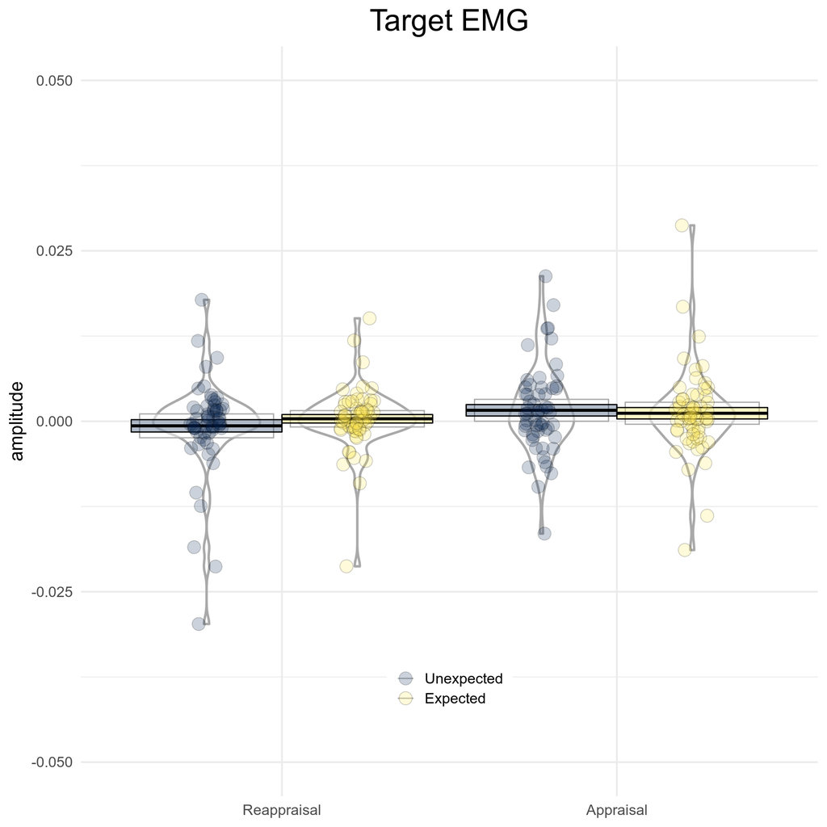

**Figure 3.** EMG amplitude in response to target. **Note**: 9 values are outside the plot.

```r
# plot
EMG_target %>%
  ggplot(
    aes(
      x = ER_Strategy,
      y = amplitude,
      color = Expectation,
      fill = Expectation
    )
  ) +
  geom_pirate(
    bars = FALSE,
    cis = TRUE,
    lines = TRUE, lines_params = list(color = "black", alpha = .3),
    points = TRUE, points_params = list(color = "black", shape = 21, size = 5, alpha = .2),
    violins = TRUE, violins_params = list(size = 1),
    show.legend = TRUE
  ) +
  scale_color_viridis_d(option = "cividis") +
  scale_fill_viridis_d(option = "cividis") +
  scale_y_continuous(limits = c(-.05, .05)) +
  ggtitle("Target EMG") +
  theme_custom +
  theme(
    legend.position = c(.5, .15),
    axis.title.x = element_blank()
  )
```

## Analysis

Repeated measures nonparametric ANOVA (Aligned Rank Transform), post-hoc Paired Samples Wilcoxon Tests.

```r
# repeated measures nonparametric ANOVA, Aligned Rank Transform
target_ART <- anova(
  art(amplitude ~ ER_Strategy * Expectation + Error(Participant),
    data = EMG_target
  )
) %>%
  mutate(
    eta.sq.part = `Sum Sq` / (`Sum Sq` + `Sum Sq.res`) # partial eta squared
  )

target_ART %>%
  dplyr::select(`Term`, `Df`, `Df.res`, `F` = `F value`, p.value = `Pr(>F)`, `eta.sq.part`) %>%
  kable(.,
    digits = c(0, 0, 0, 2, 3, 3),
    caption = "Repeated measures nonparametric ANOVA (Aligned Rank Transform)."
  ) %>%
  kable_styling(bootstrap_options = c("striped", "hover", "condensed", "responsive"))
```

Repeated measures nonparametric ANOVA (Aligned Rank Transform).

| Term | Df | Df.res | F | p.value | eta.sq.part |
| --- | --- | --- | --- | --- | --- |
| ER_Strategy | 1 | 180 | 5.7 | 0.018 | 0.031 |
| Expectation | 1 | 180 | 0.0 | 0.987 | 0.000 |
| ER_Strategy:Expectation | 1 | 180 | 7.3 | 0.007 | 0.039 |

```r
## post-hoc analyses
# Appraisal, Expected vs. Unexpected
# Paired Samples Wilcoxon Test
EMG_Appraisal_ExpectedUnexpected_Wilcoxon <-
  wilcox.test(filter(EMG_target, ER_Strategy == "Appraisal" & Expectation == "Expected")$amplitude,
    filter(EMG_target, ER_Strategy == "Appraisal" & Expectation == "Unexpected")$amplitude,
    alternative = "two.sided",
    mu = 0,
    paired = TRUE,
    exact = TRUE,
    correct = TRUE,
    conf.int = TRUE, conf.level = 0.95
  )

# effect size r
EMG_Appraisal_ExpectedUnexpected_r <-
  wilcoxonPairedR(filter(EMG_target, ER_Strategy == "Appraisal" & Expectation %in% c("Expected", "Unexpected"))$amplitude,
    filter(EMG_target, ER_Strategy == "Appraisal" & Expectation %in% c("Expected", "Unexpected"))$Expectation,
    ci = TRUE, conf = 0.95,
    type = "bca", R = 5000,
    cases = TRUE
  )

# Reappraisal, Expected vs. Unexpected
# Paired Samples Wilcoxon Test
EMG_Reappraisal_ExpectedUnexpected_Wilcoxon <-
  wilcox.test(filter(EMG_target, ER_Strategy == "Reappraisal" & Expectation == "Expected")$amplitude,
    filter(EMG_target, ER_Strategy == "Reappraisal" & Expectation == "Unexpected")$amplitude,
    alternative = "two.sided",
    mu = 0,
    paired = TRUE,
    exact = TRUE,
    correct = TRUE,
    conf.int = TRUE, conf.level = 0.95
  )

# effect size r
EMG_Reappraisal_ExpectedUnexpected_r <-
  wilcoxonPairedR(filter(EMG_target, ER_Strategy == "Reappraisal" & Expectation %in% c("Expected", "Unexpected"))$amplitude,
    filter(EMG_target, ER_Strategy == "Reappraisal" & Expectation %in% c("Expected", "Unexpected"))$Expectation,
    ci = TRUE, conf = 0.95,
    type = "bca", R = 5000,
    cases = TRUE
  )

# Expected, Appraisal vs. Reappraisal
# Paired Samples Wilcoxon Test
EMG_Expected_AppraisalReappraisal_Wilcoxon <-
  wilcox.test(filter(EMG_target, ER_Strategy == "Appraisal" & Expectation == "Expected")$amplitude,
    filter(EMG_target, ER_Strategy == "Reappraisal" & Expectation == "Expected")$amplitude,
    alternative = "two.sided",
    mu = 0,
    paired = TRUE,
    exact = TRUE,
    correct = TRUE,
    conf.int = TRUE, conf.level = 0.95
  )

# effect size r
EMG_Expected_AppraisalReappraisal_r <-
  wilcoxonPairedR(filter(EMG_target, ER_Strategy %in% c("Appraisal", "Reappraisal") & Expectation == "Expected")$amplitude,
    filter(EMG_target, ER_Strategy %in% c("Appraisal", "Reappraisal") & Expectation == "Expected")$ER_Strategy,
    ci = TRUE, conf = 0.95,
    type = "bca", R = 5000,
    cases = TRUE
  )

# Unexpected, Appraisal vs. Reappraisal
# Paired Samples Wilcoxon Test
EMG_Unexpected_AppraisalReappraisal_Wilcoxon <-
  wilcox.test(filter(EMG_target, ER_Strategy == "Appraisal" & Expectation == "Unexpected")$amplitude,
    filter(EMG_target, ER_Strategy == "Reappraisal" & Expectation == "Unexpected")$amplitude,
    alternative = "two.sided",
    mu = 0,
    paired = TRUE,
    exact = TRUE,
    correct = TRUE,
    conf.int = TRUE, conf.level = 0.95
  )

# effect size r
EMG_Unexpected_AppraisalReappraisal_r <-
  wilcoxonPairedR(filter(EMG_target, ER_Strategy %in% c("Appraisal", "Reappraisal") & Expectation == "Unexpected")$amplitude,
    filter(EMG_target, ER_Strategy %in% c("Appraisal", "Reappraisal") & Expectation == "Unexpected")$ER_Strategy,
    ci = TRUE, conf = 0.95,
    type = "bca", R = 5000,
    cases = TRUE
  )

# summary
target_ART_posthoc <- tibble(
  "comparison" = c(
    "Appraisal, Expected vs. Unexpected", "Reappraisal, Expected vs. Unexpected",
    "Expected, Appraisal vs. Reappraisal", "Unexpected, Appraisal vs. Reappraisal"
  ),
  "V" = c(
    EMG_Appraisal_ExpectedUnexpected_Wilcoxon$statistic, EMG_Reappraisal_ExpectedUnexpected_Wilcoxon$statistic,
    EMG_Expected_AppraisalReappraisal_Wilcoxon$statistic, EMG_Unexpected_AppraisalReappraisal_Wilcoxon$statistic
  ),
  "p" = c(
    EMG_Appraisal_ExpectedUnexpected_Wilcoxon$p.value, EMG_Reappraisal_ExpectedUnexpected_Wilcoxon$p.value,
    EMG_Expected_AppraisalReappraisal_Wilcoxon$p.value, EMG_Unexpected_AppraisalReappraisal_Wilcoxon$p.value
  ),
  "r" = c(
    EMG_Appraisal_ExpectedUnexpected_r$r, EMG_Reappraisal_ExpectedUnexpected_r$r,
    EMG_Expected_AppraisalReappraisal_r$r, EMG_Unexpected_AppraisalReappraisal_r$r
  ),
  "CI95_lower" = c(
    EMG_Appraisal_ExpectedUnexpected_r$lower.ci, EMG_Reappraisal_ExpectedUnexpected_r$lower.ci,
    EMG_Expected_AppraisalReappraisal_r$lower.ci, EMG_Unexpected_AppraisalReappraisal_r$lower.ci
  ),
  "CI95_upper" = c(
    EMG_Appraisal_ExpectedUnexpected_r$upper.ci, EMG_Reappraisal_ExpectedUnexpected_r$upper.ci,
    EMG_Expected_AppraisalReappraisal_r$upper.ci, EMG_Unexpected_AppraisalReappraisal_r$upper.ci
  )
) %>%
  mutate("p" = p.adjust(p, method = "holm")) # Bonferroni-Holm correction on post-hoc tests

kable(target_ART_posthoc,
  digits = c(0, 0, 3, 2, 2, 2),
  caption = "Post-hoc Repeated Samples Wilcoxon tests (Bonferroni-Holm p-value correction), bootstrapped effect size."
) %>%
  kable_styling(bootstrap_options = c("striped", "hover", "condensed", "responsive"))
```

Post-hoc Repeated Samples Wilcoxon tests (Bonferroni-Holm p-value correction), bootstrapped effect size.

| comparison | V | p | r | CI95_lower | CI95_upper |
| --- | --- | --- | --- | --- | --- |
| Appraisal, Expected vs. Unexpected | 778 | 0.593 | 0.15 | -0.10 | 0.39 |
| Reappraisal, Expected vs. Unexpected | 1126 | 0.593 | -0.17 | -0.40 | 0.09 |
| Expected, Appraisal vs. Reappraisal | 1038 | 0.593 | -0.08 | -0.34 | 0.18 |
| Unexpected, Appraisal vs. Reappraisal | 1377 | 0.007 | -0.40 | -0.59 | -0.15 |

# Exploratory Analysis

## Block order

Participants with even numbers started with reappraisal blocks, participants with uneven numbers started with appraisal block. Does block order influence EMG amplitude?

```r
EMG <- EMG %>%
  mutate(
    start_block = as_factor(
      ifelse(
        as.numeric(Participant) %% 2 == 0,
        "start_Reappraisal",
        "start_Appraisal"
      )
    )
  )
```

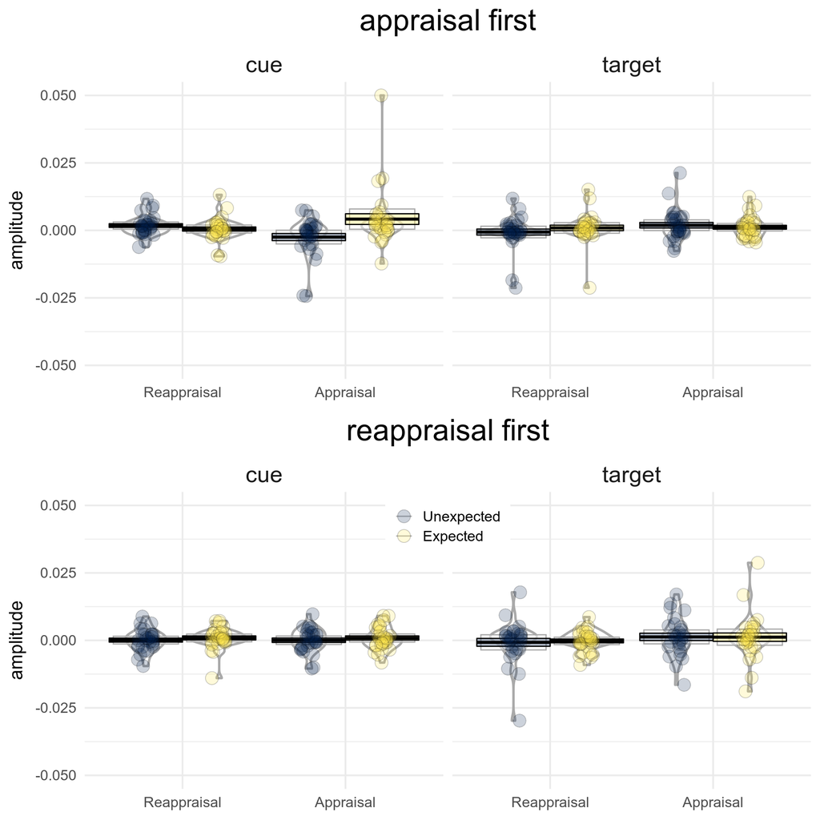

```r
# plot start appraisal
plot_start_appraisal <-
  EMG %>%
  filter(start_block == "start_Appraisal") %>%
  ggplot(
    aes(
      x = ER_Strategy,
      y = amplitude,
      color = Expectation,
      fill = Expectation
    )
  ) +
  geom_pirate(
    bars = FALSE,
    cis = TRUE,
    lines = TRUE, lines_params = list(color = "black", alpha = .3),
    points = TRUE, points_params = list(color = "black", shape = 21, size = 5, alpha = .2),
    violins = TRUE, violins_params = list(size = 1),
    show.legend = TRUE
  ) +
  scale_color_viridis_d(option = "cividis") +
  scale_fill_viridis_d(option = "cividis") +
  scale_y_continuous(limits = c(-.05, .05)) +
  ggtitle("appraisal first") +
  facet_wrap(. ~ Stimulus) +
  theme_custom +
  theme(
    legend.position = c(.55, .8),
    axis.title.x = element_blank()
  )

# plot start reappraisal
plot_start_reappraisal <-
  EMG %>%
  filter(start_block == "start_Reappraisal") %>%
  ggplot(
    aes(
      x = ER_Strategy,
      y = amplitude,
      color = Expectation,
      fill = Expectation
    )
  ) +
  geom_pirate(
    bars = FALSE,
    cis = TRUE,
    lines = TRUE, lines_params = list(color = "black", alpha = .3),
    points = TRUE, points_params = list(color = "black", shape = 21, size = 5, alpha = .2),
    violins = TRUE, violins_params = list(size = 1),
    show.legend = TRUE
  ) +
  scale_color_viridis_d(option = "cividis") +
  scale_fill_viridis_d(option = "cividis") +
  scale_y_continuous(limits = c(-.05, .05)) +
  ggtitle("reappraisal first") +
  facet_wrap(. ~ Stimulus) +
  theme_custom +
  theme(
    legend.position = c(.45, .2),
    axis.title.x = element_blank()
  )

# arrange plots in two columns
plot_block_data <- plot_grid(
  plot_start_appraisal + theme(legend.position = "none"),
  plot_start_reappraisal + theme(legend.position = c(.5, .9)),
  align = "vh",
  hjust = -1,
  nrow = 2
)

plot_block_data
```

The package `ARTool` does not handle split-plot designs, therefore we will run non-parametric permutation tests via the function `ezPerm` from the package `ez`.

```r
block_ez <-
  ezPerm(
    data = EMG,
    dv = amplitude,
    wid = Participant,
    within = c(Stimulus, ER_Strategy, Expectation),
    between = start_block,
    perms = 1000
  )

saveRDS(block_ez, file = paste0(getwd(), "/block_ez.rds"), compress = "gzip")
```

```r
block_ez <- readRDS(paste0(getwd(), "/block_ez.rds"))

block_ez %>%
  kable(.,
    digits = c(0, 3, 0),
    caption = "Split-plot ANOVA, control for block order (Appraisal first or Reappraisal first)."
  ) %>%
  kable_styling(bootstrap_options = c("striped", "hover", "condensed", "responsive"))
```

Split-plot ANOVA, control for block order (Appraisal first or Reappraisal first).

Effect

p

p<.05

start_block

0.701

Stimulus

0.811

ER_Strategy

0.112

Expectation

0.936

start_block:Stimulus

0.473

start_block:ER_Strategy

0.411

Stimulus:ER_Strategy

0.657

start_block:Expectation

0.318

Stimulus:Expectation

0.433

ER_Strategy:Expectation

0.539

start_block:Stimulus:ER_Strategy

0.097

start_block:Stimulus:Expectation

0.954

start_block:ER_Strategy:Expectation

0.734

Stimulus:ER_Strategy:Expectation

0.015

start_block:Stimulus:ER_Strategy:Expectation

0.807

Results are **not** influenced by block order.

## Correlation

Reviewer’s comment:

> It seems as though the primary difference during the target phase is for unexpected negative feedback, and it is reduced for reappraised vs. appraised trials. Does something going on during anticipation predict this effect? For example, does the difference in reappraise vs. appraise during anticipation of unexpected feedback (or something else during anticipation) correlate/predict this effect?

```r
EMG_Unexpected_corr <- EMG %>%
  filter(
    Expectation == "Unexpected"
  ) %>%
  dplyr::select(Participant, Stimulus, ER_Strategy, amplitude) %>%
  pivot_wider(
    id_cols = Participant,
    names_from = c(Stimulus, ER_Strategy),
    values_from = amplitude
  ) %>%
  mutate(
    cue_ReappraisalVsAppraisal = cue_Reappraisal - cue_Appraisal,
    target_ReappraisalVsAppraisal = target_Reappraisal - target_Appraisal
  ) %>%
  dplyr::select(Participant, cue_ReappraisalVsAppraisal, target_ReappraisalVsAppraisal)

# Spearman's correlation
corr <- cor.test(
  x = pull(EMG_Unexpected_corr, "cue_ReappraisalVsAppraisal"),
  y = pull(EMG_Unexpected_corr, "target_ReappraisalVsAppraisal"),
  method = "spearman",
  alternative = "two.sided",
  exact = TRUE,
  continuity = TRUE
)

tibble(
  "rho" = corr$statistic,
  "p-value" = corr$p.value
) %>%
  kable(.,
    digits = c(0, 3),
    caption = ""
  ) %>%
  kable_styling(bootstrap_options = c("striped", "hover", "condensed", "responsive"))
```

| rho | p-value |
| --- | --- |
| 40138 | 0.64 |

The difference between Appraisal and Reappraisal during anticipation does **not** statistically correlate with the same difference during the target phase.